# TidyModels: modeltime + cross-validation + hyperparameter-tuning

UPDATE: 2022-12-24 17:18:26

# はじめに

`tidymodels`パッケージの使い方をいくつかのノートに分けてまとめている。`tidymodels`パッケージは、統計モデルや機械学習モデルを構築するために必要なパッケージをコレクションしているパッケージで、非常に色んなパッケージがある。ここでは、今回は`modeltime`パッケージ + `cross-validation` + `hyperparameter-tuning`についてまとめていく。モデルの数理的な側面や機械学習の用語などは、このノートでは扱わない。

下記の公式ドキュメントや`tidymodels`パッケージに関する書籍を参考にしている。

- [Tidymodels](https://www.tidymodels.org/)
- [Tidy Modeling with R](https://www.tmwr.org/software-modeling.html)

## `modeltime`パッケージの目的

`modeltime`パッケージは、時系列モデルの構築を効率よく行うためのパッケージで、`tidymodels`パッケージと組み合わせて時系列モデルを作成する際に使用される。時系列予測のための体系的なワークフローを提供し、時系列ブーストモデルなど新しいアルゴリズムもカバーしている点が特徴的。

前回は基本的な使い方をまとめており、時系列モデルのハイパーパラメータチューニングを扱う。

- [Hyperparameter Tuning with Boostime](https://albertoalmuinha.com/posts/2021-06-28-boostime-tuning/parameter-tuning-boostime/?panelset1=slice2-m2&panelset2=m12&panelset=m2)

上記のサイトをなぞりながら、不明点を追記しながらまとめていく。

## モデルの作成

まずは必要なパッケージを読み込んでおく。

```r
library(tidymodels)
library(tidyverse)
library(modeltime)
library(timetk)
library(DT)
```

前回同様、ここでも`timetk`パッケージ内の`m4_monthly`データセットの`id`が`M750`の部分を使用する。

```r
m4_monthly %>%
  filter(id == "M750") %>%
  tk_summary_diagnostics(date)
```

```
## # A tibble: 1 × 12
##   n.obs start      end        units scale tzone diff.m…¹ diff.q1 diff.…² diff.…³
##   <int> <date>     <date>     <chr> <chr> <chr>    <dbl>   <dbl>   <dbl>   <dbl>
## 1   306 1990-01-01 2015-06-01 days  month UTC    2419200 2592000 2678400  2.63e6
## # … with 2 more variables: diff.q3 <dbl>, diff.maximum <dbl>, and abbreviated
## #   variable names ¹diff.minimum, ²diff.median, ³diff.mean
```

データは、1990-01-01から始まり、2015-06-01まである。レコード数は306レコードで、間隔は月単位のデータになっている。

```r
m750 <- m4_monthly %>% filter(id == "M750") %>% select(-id)
m750 %>% datatable()
```

|  | date | value |
| --- | --- | --- |
| 1 | 1990-01-01 | 6370 |
| 2 | 1990-02-01 | 6430 |
| 3 | 1990-03-01 | 6520 |
| 4 | 1990-04-01 | 6580 |
| 5 | 1990-05-01 | 6620 |
| 6 | 1990-06-01 | 6690 |
| 7 | 1990-07-01 | 6000 |
| 8 | 1990-08-01 | 5450 |
| 9 | 1990-09-01 | 6480 |
| 10 | 1990-10-01 | 6820 |

[output cut: 296 more lines]

グラフ化しておく。

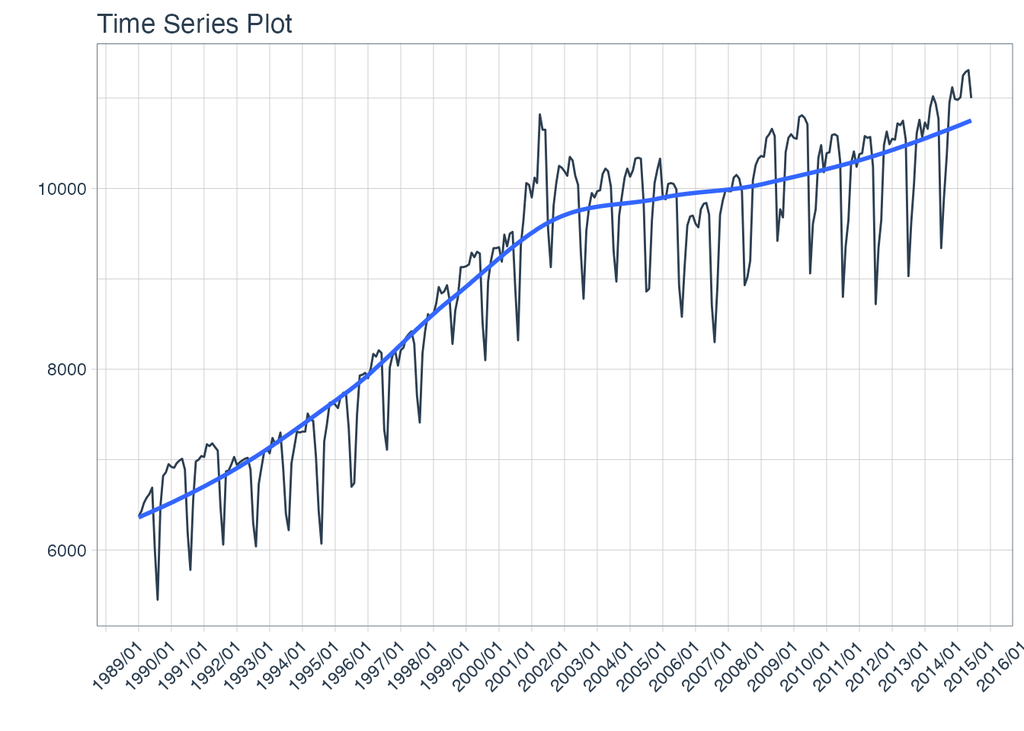

```r
m750 %>%
  plot_time_series(.data = ., .date_var = date, .value = value, .interactive = FALSE) +
  scale_x_date(limits = c(as.Date("1990-01-01"), as.Date("2015-06-01")),
               labels = date_format("%Y/%m"),
               breaks = date_breaks("1 year")) +
  theme(axis.text.x = element_text(angle = 45, vjust = 0.2, hjust=0.2))
```

ここでは最終的に12ヶ月の予測を試みる。まずは、予測する分だけデータフレームを拡張する。これは`future_frame`関数で実行でき、2015-07-01から2016-06-01まで、データフレームが拡張されていることがわかる。

```r
m750_extend <- m750 %>%
  future_frame(
        .length_out = 12,
        .bind_data  = TRUE
    )
m750_extend %>% datatable()
```

|  | date | value |
| --- | --- | --- |
| 1 | 1990-01-01 | 6370 |
| 2 | 1990-02-01 | 6430 |
| 3 | 1990-03-01 | 6520 |
| 4 | 1990-04-01 | 6580 |
| 5 | 1990-05-01 | 6620 |
| 6 | 1990-06-01 | 6690 |
| 7 | 1990-07-01 | 6000 |
| 8 | 1990-08-01 | 5450 |
| 9 | 1990-09-01 | 6480 |
| 10 | 1990-10-01 | 6820 |

[output cut: 308 more lines]

拡張したデータを学習データ、テストデータ、予測用データに再分割する。

```r
# 2015-07-01から2016-06-01(n=12)
df_future <- m750_extend %>% filter(is.na(value))
# 1990-01-01から2015-06-01(n=306)
df <- m750_extend %>% filter(!is.na(value))

# <Training/Testing/Total>
# <275/31/306>
df_init   <- initial_time_split(df, 0.9)
df_train  <- df_init %>% training()
df_test   <- df_init %>% testing()

bind_rows(
  df_train %>% summarise(n.obs = n(), start = min(date), end = max(date)) %>% mutate(tag = "train"),
  df_test %>% summarise(n.obs = n(), start = min(date), end = max(date)) %>% mutate(tag = "test"),
  df_future %>% summarise(n.obs = n(), start = min(date), end = max(date)) %>% mutate(tag = "forecast")
)
```

```
## # A tibble: 3 × 4
##   n.obs start      end        tag
##   <int> <date>     <date>     <chr>
## 1   275 1990-01-01 2012-11-01 train
## 2    31 2012-12-01 2015-06-01 test
## 3    12 2015-07-01 2016-06-01 forecast
```

学習データをクロスバリデーション用に分割する。学習データに5年、評価データに2年、フォールド間のスキップは1年で、分割数は5とする。

```r
m750_resamples <- df_train %>%
  time_series_cv(
    date_var    = date,
    initial     = "5 years",
    assess      = "2 years",
    skip        = "1 years",
    cumulative  = TRUE,
    slice_limit = 5
  )

m750_resamples %>%
 tk_time_series_cv_plan() %>%
 group_by(.id) %>%
 summarise(min = min(date), max = max(date))
```

```
## # A tibble: 5 × 3
##   .id    min        max
##   <chr>  <date>     <date>
## 1 Slice1 1990-01-01 2012-11-01
## 2 Slice2 1990-01-01 2011-11-01
## 3 Slice3 1990-01-01 2010-11-01
## 4 Slice4 1990-01-01 2009-11-01
## 5 Slice5 1990-01-01 2008-11-01
```

クロスバリデーションの様子を`plot_time_series_cv_plan`関数で可視化しておく。

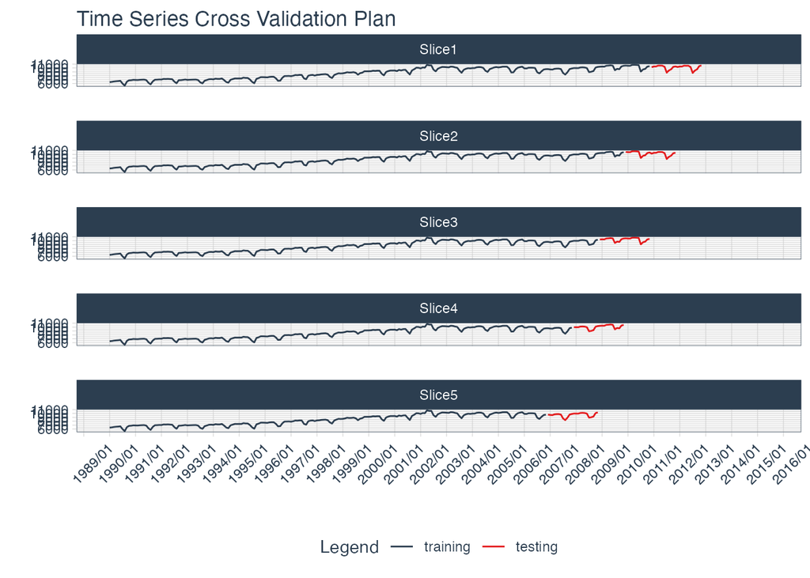

```r
m750_resamples %>%
  tk_time_series_cv_plan() %>%
  plot_time_series_cv_plan(.date_var = date, .value = value, .interactive = FALSE, .facet_ncol  = 1) +
  scale_x_date(limits = c(as.Date("1990-01-01"), as.Date("2015-06-01")),
               labels = date_format("%Y/%m"),
               breaks = date_breaks("1 year")) +
  theme(axis.text.x = element_text(angle = 45, vjust = 0.2, hjust=0.2))
```

データの分割が終わったので、レシピの設定を行なう。`step_times_series_signature`関数を使用して、日付から多数の特徴量を生成する。

```r
recipe <- recipe(value ~ ., training(m750_resamples$splits[[1]])) %>%
  step_timeseries_signature(date) %>%
  step_rm(matches("(.iso$)|(.xts$)|(day)|(hour)|(minute)|(second)|(am.pm)")) %>%
  step_rm("date_index.num") %>%
  step_mutate(date_month = factor(date_month, ordered = TRUE)) %>%
  step_dummy(all_nominal(), one_hot = TRUE)

recipe %>% prep() %>% bake(df_test) %>% datatable()
```

|  | date | value | date_year | date_half | date_quarter | date_mweek | date_week | date_week2 | date_week3 | date_week4 | date_month_01 | date_month_02 | date_month_03 | date_month_04 | date_month_05 | date_month_06 | date_month_07 | date_month_08 | date_month_09 | date_month_10 | date_month_11 | date_month_12 | date_month.lbl_01 | date_month.lbl_02 | date_month.lbl_03 | date_month.lbl_04 | date_month.lbl_05 | date_month.lbl_06 | date_month.lbl_07 | … |
| --- | --- | --- | --- | --- | --- | --- | --- | --- | --- | --- | --- | --- | --- | --- | --- | --- | --- | --- | --- | --- | --- | --- | --- | --- | --- | --- | --- | --- | --- | --- |
| 1 | 2012-12-01 | 10490 | 2012 | 2 | 4 | 1 | 48 | 0 | 0 | 0 | 0 | 0 | 0 | 0 | 0 | 0 | 0 | 0 | 0 | 0 | 0 | 1 | 0 | 0 | 0 | 0 | 0 | 0 | 0 | … |
| 2 | 2013-01-01 | 10550 | 2013 | 1 | 1 | 1 | 1 | 1 | 1 | 1 | 1 | 0 | 0 | 0 | 0 | 0 | 0 | 0 | 0 | 0 | 0 | 0 | 1 | 0 | 0 | 0 | 0 | 0 | 0 | … |
| 3 | 2013-02-01 | 10540 | 2013 | 1 | 1 | 1 | 5 | 1 | 2 | 1 | 0 | 1 | 0 | 0 | 0 | 0 | 0 | 0 | 0 | 0 | 0 | 0 | 0 | 1 | 0 | 0 | 0 | 0 | 0 | … |
| 4 | 2013-03-01 | 10720 | 2013 | 1 | 1 | 1 | 9 | 1 | 0 | 1 | 0 | 0 | 1 | 0 | 0 | 0 | 0 | 0 | 0 | 0 | 0 | 0 | 0 | 0 | 1 | 0 | 0 | 0 | 0 | … |
| 5 | 2013-04-01 | 10700 | 2013 | 1 | 2 | 1 | 13 | 1 | 1 | 1 | 0 | 0 | 0 | 1 | 0 | 0 | 0 | 0 | 0 | 0 | 0 | 0 | 0 | 0 | 0 | 1 | 0 | 0 | 0 | … |
| 6 | 2013-05-01 | 10750 | 2013 | 1 | 2 | 1 | 18 | 0 | 0 | 2 | 0 | 0 | 0 | 0 | 1 | 0 | 0 | 0 | 0 | 0 | 0 | 0 | 0 | 0 | 0 | 0 | 1 | 0 | 0 | … |
| 7 | 2013-06-01 | 10540 | 2013 | 1 | 2 | 1 | 22 | 0 | 1 | 2 | 0 | 0 | 0 | 0 | 0 | 1 | 0 | 0 | 0 | 0 | 0 | 0 | 0 | 0 | 0 | 0 | 0 | 1 | 0 | … |
| 8 | 2013-07-01 | 9030 | 2013 | 2 | 3 | 1 | 26 | 0 | 2 | 2 | 0 | 0 | 0 | 0 | 0 | 0 | 1 | 0 | 0 | 0 | 0 | 0 | 0 | 0 | 0 | 0 | 0 | 0 | 1 | … |
| 9 | 2013-08-01 | 9620 | 2013 | 2 | 3 | 1 | 31 | 1 | 1 | 3 | 0 | 0 | 0 | 0 | 0 | 0 | 0 | 1 | 0 | 0 | 0 | 0 | 0 | 0 | 0 | 0 | 0 | 0 | 0 | … |
| 10 | 2013-09-01 | 10050 | 2013 | 2 | 3 | 1 | 35 | 1 | 2 | 3 | 0 | 0 | 0 | 0 | 0 | 0 | 0 | 0 | 1 | 0 | 0 | 0 | 0 | 0 | 0 | 0 | 0 | 0 | 0 | … |

[output cut: 21 more lines]

データの分割が終わったので、パラメタのチューニングを行なうためのモデルの設定を行なう。今回はProphetBoostモデルを利用する。Prophet Boostモデルは、Prophet と XGBoost を組み合わせたアルゴリズムで、ワークフローを使用してモデルを設定できる。細かい数理的な部分は追えてないのでわからないが、おそらくこういうことだと思われる。

1. Prophet で単変量時系列へのモデリング
2. 前処理レシピで提供される外部予測変数を使用し、XGBoost モデルを使用してProphetの残差を回帰。

Prophetは時系列データを様々な要素分解(成長関数、周期性、祝日効果など)して、変化点を検出しながら、モデルを組み立てることができ、時系列データに特化したPropehetでまず予測値を得る。そこから残差を観測値として、XGBoostモデルが学習を繰り返すことで予測モデルが学習していく。

```r
prophet_boost <-
  modeltime::prophet_boost(
    # prophet
    growth = "linear",
    changepoint_num = tune(),
    changepoint_range = tune(),
    seasonality_yearly = TRUE,
    seasonality_weekly = FALSE, # Monthlyデータなので機能しない
    seasonality_daily  = FALSE, # Monthlyデータなので機能しない
    season = "multiplicative",
    prior_scale_changepoints = tune(),
    prior_scale_seasonality = tune(),
    # prior_scale_holidays = NULL,
    # xgboost
    trees = 1000,
    sample_size = c(0.1, 1),
    # mtryを設定すると場合によってはエラーになる。原因不明。
    mtry = tune(),
    tree_depth = tune(),
    learn_rate = tune(),
    stop_iter = tune(),
    min_n = tune(),
    # loss_reduction = tune(),
  ) %>%
  set_engine('prophet_xgboost')

prophet_boost
```

```
## PROPHET Regression Model Specification (regression)
##
## Main Arguments:
##   growth = linear
##   changepoint_num = tune()
##   changepoint_range = tune()
##   seasonality_yearly = TRUE
##   seasonality_weekly = FALSE
##   seasonality_daily = FALSE
##   season = multiplicative
##   prior_scale_changepoints = tune()
##   prior_scale_seasonality = tune()
##   mtry = tune()
##   trees = 1000
##   min_n = tune()
##   tree_depth = tune()
##   learn_rate = tune()
##   sample_size = c(0.1, 1)
##   stop_iter = tune()
##
## Computational engine: prophet_xgboost
```

モデルのハイパーパラメーターの調整は`tidymodels`のモデリングフレームワークに従い、`workflows`パッケージの関数でワークフローを作成して行なう。

```r
workflow <- workflow() %>%
    add_model(prophet_boost) %>%
    add_recipe(recipe)
workflow
```

```
## ══ Workflow ════════════════════════════════════════════════════════════════════
## Preprocessor: Recipe
## Model: prophet_boost()
##
## ── Preprocessor ────────────────────────────────────────────────────────────────
## 5 Recipe Steps
##
## • step_timeseries_signature()
## • step_rm()
## • step_rm()
## • step_mutate()
## • step_dummy()
##
## ── Model ───────────────────────────────────────────────────────────────────────
## PROPHET Regression Model Specification (regression)
##
## Main Arguments:
##   growth = linear
##   changepoint_num = tune()
##   changepoint_range = tune()
##   seasonality_yearly = TRUE
##   seasonality_weekly = FALSE
##   seasonality_daily = FALSE
##   season = multiplicative
##   prior_scale_changepoints = tune()
##   prior_scale_seasonality = tune()
##   mtry = tune()
##   trees = 1000
##   min_n = tune()
##   tree_depth = tune()
##   learn_rate = tune()
##   sample_size = c(0.1, 1)
##   stop_iter = tune()
##
## Computational engine: prophet_xgboost
```

そして、`tune_grid`関数を使用して、クロスバリデーションでパラメタの最適値を探索する。ただ、私が`modeltimes`パッケージやProphetBoostモデルを理解してないためか、多数のエラー、ワーニングが出る…。

```r
set.seed(1989)
tune_results <- tune_grid(
    object     = workflow,
    resamples  = m750_resamples,
    param_info = parameters(workflow),
    grid       = 30,
    metrics = metric_set(rmse, mae, mape)
    )
```

パラメタの組み合わせを見るときは、`show_best`関数で取り出す。ここでは`mape`基準でクロスバリデーションの結果を確認する。

```r
tune_results %>%
  show_best(n = 10, metric = "mape") %>%
  datatable()
```

|  | changepoint_num | changepoint_range | prior_scale_changepoints | prior_scale_seasonality | mtry | min_n | tree_depth | learn_rate | stop_iter | .metric | .estimator | mean | n | std_err | .config |
| --- | --- | --- | --- | --- | --- | --- | --- | --- | --- | --- | --- | --- | --- | --- | --- |
| 1 | 20 | 0.629681361559778 | 0.00800693435048087 | 11.8613867207823 | 25 | 31 | 14 | 5.05798197161862e-05 | 17 | mape | standard | 2.59338500942401 | 4 | 0.420743957643614 | Preprocessor1_Model05 |
| 2 | 27 | 0.684148535744753 | 12.8093015466348 | 7.79906520672457 | 27 | 23 | 6 | 5.1060987898311e-10 | 5 | mape | standard | 3.70656478593689 | 4 | 1.23836545695858 | Preprocessor1_Model29 |
| 3 | 30 | 0.606111618434079 | 0.0266678091695495 | 1.13469288292091 | 10 | 14 | 5 | 1.0513720843076e-08 | 6 | mape | standard | 3.74879530431835 | 5 | 1.00993734885134 | Preprocessor1_Model08 |
| 4 | 35 | 0.69757169283228 | 1.98659154111828 | 15.6656882562837 | 21 | 3 | 10 | 0.0346527649273409 | 17 | mape | standard | 3.75654512817186 | 4 | 1.18787042531704 | Preprocessor1_Model16 |
| 5 | 8 | 0.886471625014674 | 0.020047627741818 | 0.00298750862913686 | 32 | 19 | 2 | 0.000504273333141153 | 16 | mape | standard | 4.00388365066707 | 3 | 1.28852740229362 | Preprocessor1_Model07 |
| 6 | 50 | 0.611237956178375 | 0.231726458259695 | 0.204674092975742 | 6 | 10 | 3 | 1.26074005241359e-07 | 4 | mape | standard | 4.01533382707631 | 1 |  | Preprocessor1_Model26 |
| 7 | 20 | 0.659345117032062 | 2.47444628044415 | 0.0322176910726077 | 14 | 39 | 13 | 0.000111565615435756 | 12 | mape | standard | 4.43001861709386 | 5 | 1.06446700973885 | Preprocessor1_Model13 |
| 8 | 1 | 0.639562664222904 | 0.333116398400254 | 0.00163154936790898 | 13 | 15 | 9 | 3.79322055732353e-09 | 11 | mape | standard | 4.52335712532002 | 2 | 0.416776375825506 | Preprocessor1_Model28 |
| 9 | 15 | 0.700737296948209 | 3.8123067038246 | 0.713358946981896 | 7 | 11 | 8 | 0.0893461674509588 | 10 | mape | standard | 4.61537903212922 | 4 | 1.45083858434775 | Preprocessor1_Model19 |
| 10 | 40 | 0.647778496562969 | 1.25122769578956 | 0.0127765016322119 | 4 | 35 | 11 | 1.34870923580546e-08 | 14 | mape | standard | 4.61581225189492 | 4 | 1.28005461195463 | Preprocessor1_Model12 |

あとは、ベストなバラメタを`select_best`関数で取り出して、ワークフローのパラメタを`finalize_workflow`関数で更新する。そして、取りあえずデータは何でも良いので、形式的にフィッティングしておく。

```r
tuned_best_params <- tune_results %>%
    select_best("mape")

best_workflow <- workflow %>%
    finalize_workflow(parameters = tuned_best_params)

# ここのデータはなんでもよい
model_predicted_best_workflow <- best_workflow %>%
    fit(training(m750_resamples$splits[[1]]))

model_predicted_best_workflow
```

```
## ══ Workflow [trained] ══════════════════════════════════════════════════════════
## Preprocessor: Recipe
## Model: prophet_boost()
##
## ── Preprocessor ────────────────────────────────────────────────────────────────
## 5 Recipe Steps
##
## • step_timeseries_signature()
## • step_rm()
## • step_rm()
## • step_mutate()
## • step_dummy()
##
## ── Model ───────────────────────────────────────────────────────────────────────
## PROPHET w/ XGBoost Errors
## ---
## Model 1: PROPHET
##  - growth: 'linear'
##  - n.changepoints: 20
##  - changepoint.range: 0.629681361559778
##  - yearly.seasonality: 'TRUE'
##  - weekly.seasonality: 'FALSE'
##  - daily.seasonality: 'FALSE'
##  - seasonality.mode: 'multiplicative'
##  - changepoint.prior.scale: 0.00800693435048087
##  - seasonality.prior.scale: 11.8613867207823
##  - holidays.prior.scale: 10
##  - logistic_cap: NULL
##  - logistic_floor: NULL
##
## ---
## Model 2: XGBoost Errors
##
## xgboost::xgb.train(params = list(eta = 5.05798197161862e-05,
##     max_depth = 14L, gamma = 0, colsample_bytree = 1, colsample_bynode = 0.806451612903226,
##     min_child_weight = 31L, subsample = c(0.1, 1)), data = x$data,
##     nrounds = 1000, watchlist = x$watchlist, verbose = 0, early_stopping_rounds = 17L,
##     objective = "reg:squarederror", nthread = 1)
```

ここまでくれば、`modeltime`のワークフローに戻って作業ができる。ということで、これまで通り`modeltime`のワークフローに従って、モデルテーブルに登録する。

```r
models_tbl <- modeltime_table(
    model_predicted_best_workflow
)
models_tbl
```

```
## # Modeltime Table
## # A tibble: 1 × 3
##   .model_id .model     .model_desc
##       <int> <list>     <chr>
## 1         1 <workflow> PROPHET W/ XGBOOST ERRORS
```

その後は`modeltime_calibrate`関数でテストデータに対するキャリブレーションを行なう。

```r
calibration_tbl <- models_tbl %>%
  modeltime_calibrate(df_test)

calibration_tbl %>%
  pluck(".calibration_data", 1) %>%
  datatable()
```

|  | date | .actual | .prediction | .residuals |
| --- | --- | --- | --- | --- |
| 1 | 2012-12-01 | 10490 | 10772.0682613302 | -282.068261330205 |
| 2 | 2013-01-01 | 10550 | 10714.5405191395 | -164.540519139473 |
| 3 | 2013-02-01 | 10540 | 10738.181319237 | -198.18131923695 |
| 4 | 2013-03-01 | 10720 | 10879.6341407388 | -159.634140738786 |
| 5 | 2013-04-01 | 10700 | 10919.5726293418 | -219.572629341828 |
| 6 | 2013-05-01 | 10750 | 10910.5580311341 | -160.558031134105 |
| 7 | 2013-06-01 | 10540 | 10746.5919986559 | -206.591998655938 |
| 8 | 2013-07-01 | 9030 | 9750.2430347538 | -720.243034753805 |
| 9 | 2013-08-01 | 9620 | 9469.09234159028 | 150.90765840972 |
| 10 | 2013-09-01 | 10050 | 10231.5995039032 | -181.599503903231 |

[output cut: 21 more lines]

テストデータと観測値をグラフで確認する。

```r
calibration_tbl %>%
               modeltime_forecast(
                 new_data = df_test,
                 actual_data = m750,
                 keep_data = TRUE
               ) %>%
  plot_modeltime_forecast(.interactive = TRUE, .legend_show = FALSE)
```

[interactive chart not shown]

評価指標を確認するためには`table_modeltime_accuracy`関数を利用する。

```r
calibration_tbl %>%
  modeltime_accuracy(new_data = df_test) %>%
  table_modeltime_accuracy(.interactive = FALSE)
```

Accuracy Table

| .model_id | .model_desc | .type | mae | mape | mase | smape | rmse | rsq |
| --- | --- | --- | --- | --- | --- | --- | --- | --- |
| 1 | PROPHET W/ XGBOOST ERRORS | Test | 173.25 | 1.69 | 0.59 | 1.67 | 224.3 | 0.85 |

テストデータでの検証も終わったら、あとはフルデータでモデルの再学習を行なう。

```r
refit_tbl <- calibration_tbl %>%
             modeltime_refit(data = m750)
refit_tbl
```

```
## # Modeltime Table
## # A tibble: 1 × 5
##   .model_id .model     .model_desc               .type .calibration_data
##       <int> <list>     <chr>                     <chr> <list>
## 1         1 <workflow> PROPHET W/ XGBOOST ERRORS Test  <tibble [31 × 4]>
```

その後は、当初の目的であった、2015-07-01から2016-06-01の間の予測を行なう。

```r
refit_tbl %>%
    modeltime_forecast(actual_data = m750, new_data = df_future) %>%
    plot_modeltime_forecast(.interactive = TRUE, .legend_show = FALSE)
```

[interactive chart not shown]

下記は観測値と予測値を統合したデータで、おまけとして出力する。そのまま出力しておく。

```r
refit_tbl %>%
    modeltime_forecast(actual_data = m750, new_data = df_future) %>%
  print(n = 500)
```

```
## # A tibble: 318 × 7
##     .model_id .model_desc               .key   .index     .value .conf…¹ .conf…²
##         <int> <chr>                     <fct>  <date>      <dbl>   <dbl>   <dbl>
##   1        NA ACTUAL                    actual 1990-01-01  6370      NA      NA
##   2        NA ACTUAL                    actual 1990-02-01  6430      NA      NA
##   3        NA ACTUAL                    actual 1990-03-01  6520      NA      NA
##   4        NA ACTUAL                    actual 1990-04-01  6580      NA      NA
##   5        NA ACTUAL                    actual 1990-05-01  6620      NA      NA
##   6        NA ACTUAL                    actual 1990-06-01  6690      NA      NA
##   7        NA ACTUAL                    actual 1990-07-01  6000      NA      NA
##   8        NA ACTUAL                    actual 1990-08-01  5450      NA      NA
##   9        NA ACTUAL                    actual 1990-09-01  6480      NA      NA
##  10        NA ACTUAL                    actual 1990-10-01  6820      NA      NA
##  11        NA ACTUAL                    actual 1990-11-01  6860      NA      NA
##  12        NA ACTUAL                    actual 1990-12-01  6950      NA      NA
```

[output cut: 307 more lines]

## 参考文献

- [Tidymodels](https://www.tidymodels.org/)
- [Tidy Modeling with R](https://www.tmwr.org/software-modeling.html)